# Best Batting Performance

Omolewa Adetoro

2024-09-20

In this report we will look at which team had the best batting performance using the [T20 International Cricket Matches dataset](https://www.kaggle.com/datasets/shreyasnaphad/cricket-score-predictor) which I cleaned.

## **The teams included in this dataset**

- Afghanistan
- Australia
- Bangladesh
- England
- India
- New Zealand
- Pakistan
- South Africa
- Sri Lanka
- West Indies

## **Setting up my environment**

Notes: setting up my R environment by loading “tidyverse” and “scales” packages as well as”cricket_data” the clean csv file

```r
library(tidyverse)
library(scales)
cricket_data = read.csv("~/Data Analysis Case Studies/Best Batting And Bowling Performance/clean cricket data.csv")
```

## **Findings**

Here we will look at a series of visualisations and analysis to find which teams has the best batting performance.

### **The number of games each team played**

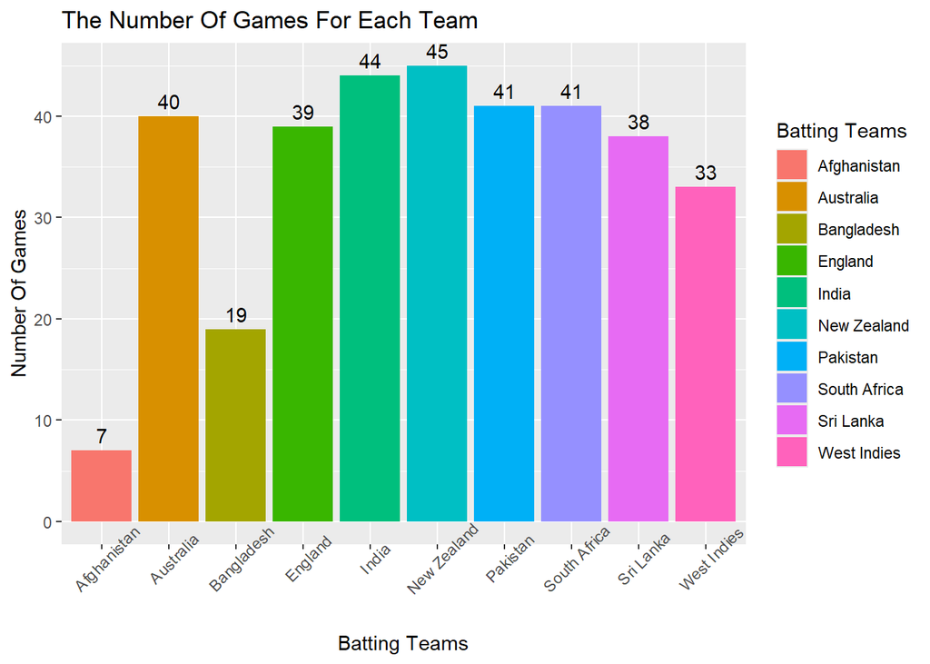

There are a total of 347 matches, and each team played various amount of games. Due to this we will be using averages to ensure the reliability of the report.

### **The average final score of each team**

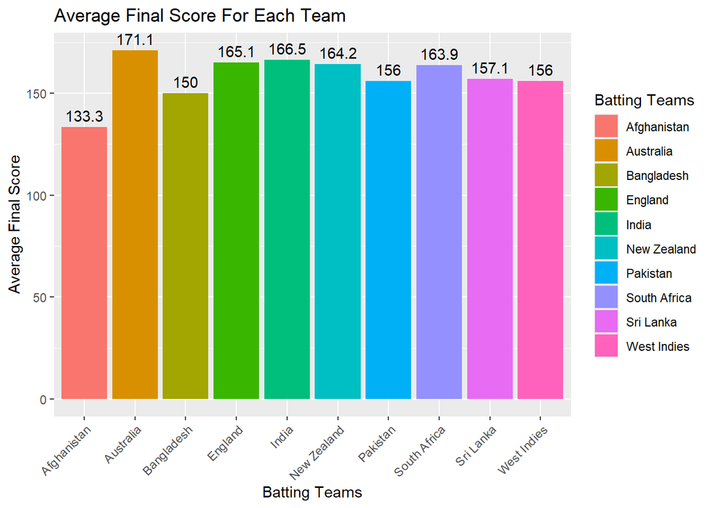

Here, we see the average scores for each team, with Australia achieving the highest and Afghanistan the lowest. However, since we are focusing on the team with the best batting performance, looking at the overall averages alone is insufficient. To get a more meaningful insight, the following visualizations and analysis will focus on scenarios where teams are performing at their peak.

The conditions I used to define a team’s best batting performance are:

- The top-order batsmen are batting
- The lower-order of batsmen are not involved
- The team is not under pressure, measured by maintaining a run rate of 7 or higher
- A powerplay has occurred
- The team shows aggression by scoring 45 or more runs in the last 5 overs.
- The tail-enders (e,g bowlers) are not involved in batting

### **The average of final score when the teams are playing at their best**

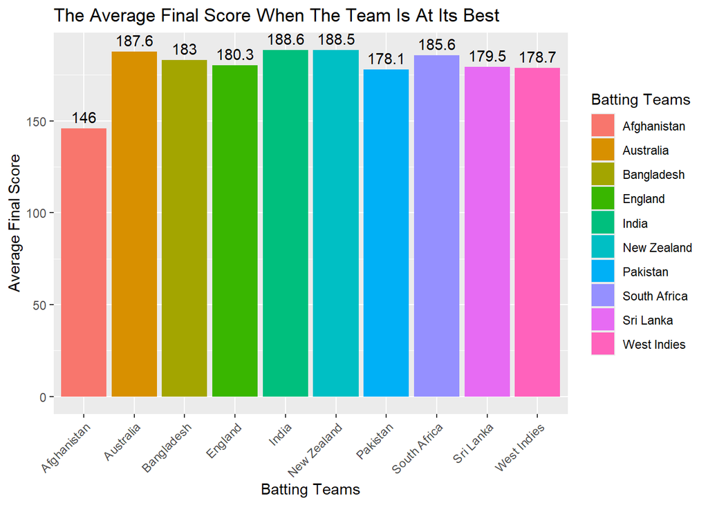

### **The average number of wickets left**

Having wickets left is beneficial for the batting team as it creates more scoring opportunities and boosts their confidence. It also adds psychological pressure on the bowling team, knowing they need to work harder to take the remaining wickets.

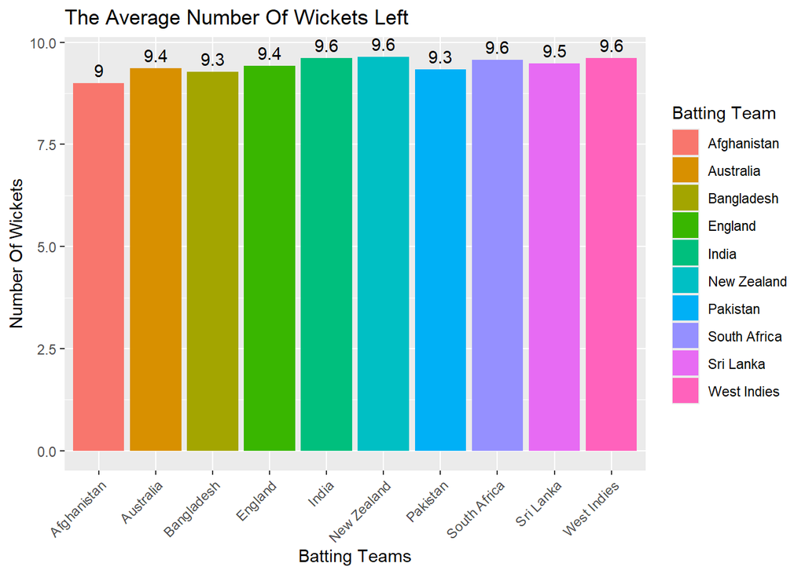

In this case, we can see that each team averaged at least 9 wickets remaining by the end of the first innings.

### **The average score of the last five overs**

The batting team typically scores the most runs during the final five overs, making this phase crucial in determining the outcome of the game.

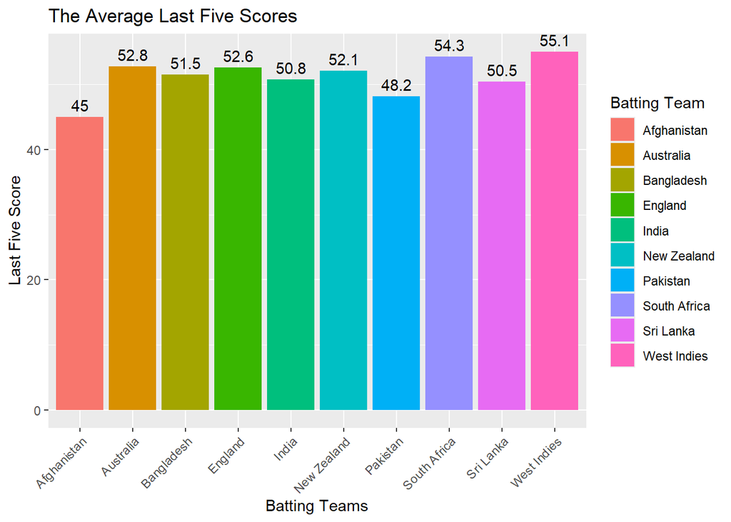

As shown here, the West Indies have achieved the highest average score during this key period.

## **Conclusion**

To identify the team with the best batting performance, I ranked them in three categories:

- Average score
- Average wickets left
- Average runs in the last five overs

Each team received a score ranging from 1 to 10, with 10 points awarded for the highest rank and 1 point for the lowest. The scores from all categories were then totaled to determine the final ranking.

### **Final ranking of the best batting performance**

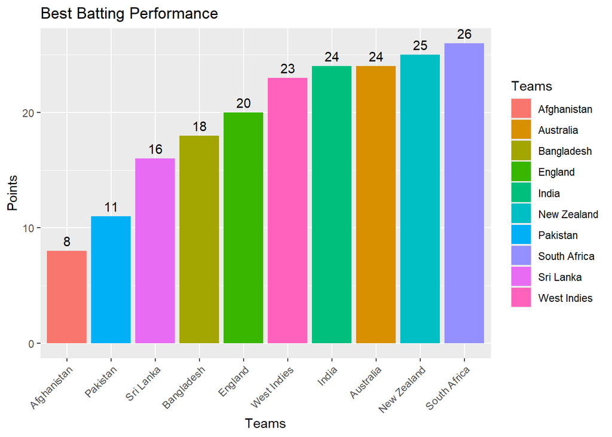

### **Best Batting Performance**

1. South Africa
2. New Zealand
3. India & Australia
4. West Indies
5. England
6. Bangladesh
7. Sri Lanka
8. Pakistan
9. Afghanistan